## Analytical Approach

> We used Pearson correlation analysis to examine the relationship between China’s solar PV panel exports and annual solar PV capacity additions across North and South American countries.

> This approach was selected to answer one of the supporting questions of our research theme: Is there a correlation between China’s solar panel export capacity (MW) and annual solar PV capacity additions (MW) in destination countries?

> We first calculated the overall correlation and then conducted separate analyses for North and South America to compare regional patterns.

## Data Validation and Diagnostics

> Before conducting the analysis, we checked for duplicate observations, missing values, and the accuracy of annual capacity additions calculations.

> We identified 15 missing values in annual capacity additions, all from 2018. These observations were excluded, leaving observations from 2019 to 2025.

## 1. Validity Check

```r
library(tidyverse)
# Load original data (before filtering)
raw_data <- read_csv(
  "~/tracyche712/data/Processed/CLEANED_Study_area_data_2018_2025.csv"
)
# 1. Check duplicates
raw_data %>%
  count(Area, Year) %>%
  filter(n > 1)
```

```
## # A tibble: 0 × 3
## # ℹ 3 variables: Area <chr>, Year <dbl>, n <int>
```

```r
# 2. Check missing values
raw_data %>%
  summarise(
    missing_exports = sum(is.na(China_panel_exports_MW)),
    missing_additions = sum(is.na(PV_capacity_additions_MW))
  )
```

```
## # A tibble: 1 × 2
##   missing_exports missing_additions
##             <int>             <int>
## 1               0                15
```

```r
#check the characteristics of missing additions
raw_data %>%
  filter(is.na(PV_capacity_additions_MW)) %>%
  select(Area, Year, PV_capacity_additions_MW)
```

```
## # A tibble: 15 × 3
##    Area           Year PV_capacity_additions_MW
##    <chr>         <dbl>                    <dbl>
##  1 Canada         2018                       NA
##  2 Mexico         2018                       NA
##  3 United States  2018                       NA
##  4 Argentina      2018                       NA
##  5 Bolivia        2018                       NA
##  6 Brazil         2018                       NA
##  7 Chile          2018                       NA
##  8 Colombia       2018                       NA
##  9 Ecuador        2018                       NA
## 10 Guyana         2018                       NA
## 11 Paraguay       2018                       NA
## 12 Peru           2018                       NA
## 13 Suriname       2018                       NA
## 14 Uruguay        2018                       NA
## 15 Venezuela      2018                       NA
```

```r
#checking correctness of capaticy addition

validation <- raw_data %>%
  arrange(Area, Year) %>%
  group_by(Area) %>%
  mutate(
    calculated_additions =
      PV_installed_capacity_MW -
      lag(PV_installed_capacity_MW),

    difference =
      PV_capacity_additions_MW -
      calculated_additions
  ) %>%
  ungroup()

# Find incorrect calculations
validation %>%
  filter(
    Year >= 2019,
    abs(difference) > 0.01
  )
```

```
## # A tibble: 0 × 14
## # ℹ 14 variables: Area <chr>, Study_scope <chr>, Year <dbl>,
## #   China_panel_exports_USD <dbl>, China_panel_exports_MW <dbl>,
## #   CleanTech_solarPV_USD <dbl>, CleanTech_alltech_USD <dbl>,
## #   PV_installed_capacity_MW <dbl>, PV_generation_GWh <dbl>, Population <dbl>,
## #   PV_capacity_additions_MW <dbl>, PV_installed_W_per_person <dbl>,
## #   calculated_additions <dbl>, difference <dbl>
```

## 2. Overall Correlation

```r
library(tidyverse)

df <- read_csv("~/tracyche712/data/Processed/CLEANED_Study_area_data_2018_2025.csv")
df <- df %>%
  filter(
    Year >= 2019,
    !is.na(China_panel_exports_MW),
    !is.na(PV_capacity_additions_MW)
  )

nrow(df)
```

```
## [1] 105
```

```r
n_distinct(df$Area)
```

```
## [1] 15
```

```r
count(df, Study_scope)
```

```
## # A tibble: 2 × 2
##   Study_scope       n
##   <chr>         <int>
## 1 North America    21
## 2 South America    84
```

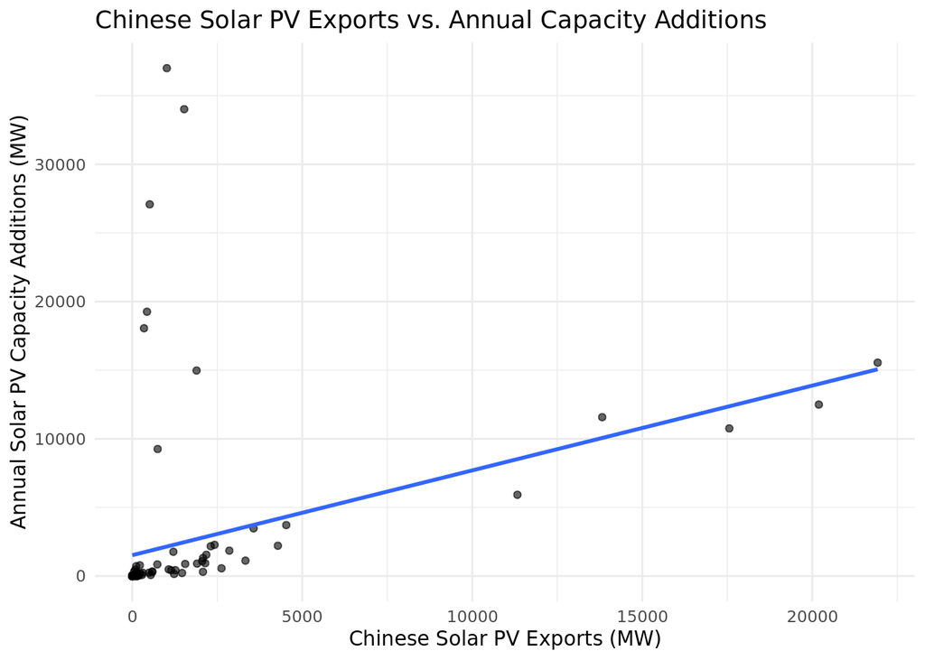

```r
ggplot(df, aes(
  x = China_panel_exports_MW,
  y = PV_capacity_additions_MW
)) +
  geom_point(alpha = 0.6) +
  geom_smooth(method = "lm", se = FALSE) +
  labs(
    title = "Chinese Solar PV Exports vs. Annual Capacity Additions",
    x = "Chinese Solar PV Exports (MW)",
    y = "Annual Solar PV Capacity Additions (MW)"
  ) +
  theme_minimal()
```

```r
#Pearson Coefficient

cor(
  df$China_panel_exports_MW,
  df$PV_capacity_additions_MW,
  method = "pearson"
)
```

```
## [1] 0.3542184
```

## 3. Regional Correlation

```r
regional_cor <- df %>%
  group_by(Study_scope) %>%
  summarise(
    n = n(),
    pearson_r = cor(
      China_panel_exports_MW,
      PV_capacity_additions_MW,
      method = "pearson"
    ),
    .groups = "drop"
  )

print(regional_cor)
```

```
## # A tibble: 2 × 3
##   Study_scope       n pearson_r
##   <chr>         <int>     <dbl>
## 1 North America    21   -0.0127
## 2 South America    84    0.986
```

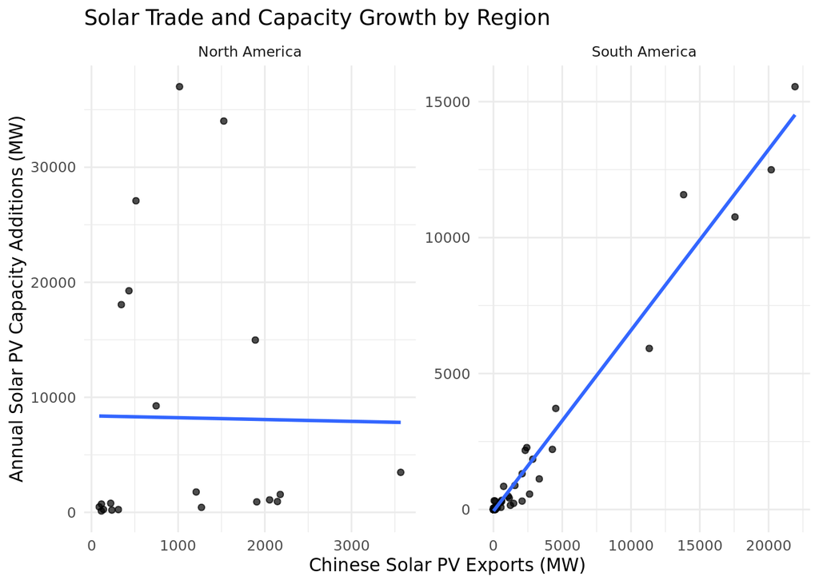

```r
ggplot(df, aes(
  x = China_panel_exports_MW,
  y = PV_capacity_additions_MW
)) +
  geom_point(alpha = 0.7) +
  geom_smooth(method = "lm", se = FALSE) +
  facet_wrap(~Study_scope, scales = "free") +
  labs(
    title = "Solar Trade and Capacity Growth by Region",
    x = "Chinese Solar PV Exports (MW)",
    y = "Annual Solar PV Capacity Additions (MW)"
  ) +
  theme_minimal()
```

## 4. Sensity Analysis

```r
# Calculate market size by country

market_size <- df %>%
  group_by(Study_scope, Area) %>%
  summarise(
    total_exports_MW = sum(China_panel_exports_MW),
    total_additions_MW = sum(PV_capacity_additions_MW),
    .groups = "drop"
  )

print(market_size, n = Inf)
```

```
## # A tibble: 15 × 4
##    Study_scope   Area          total_exports_MW total_additions_MW
##    <chr>         <chr>                    <dbl>              <dbl>
##  1 North America Canada                  1228.             2772.
##  2 North America Mexico                 14330.            10159.
##  3 North America United States           6471.           159655.
##  4 South America Argentina               2740.             2396.
##  5 South America Bolivia                   47.6             124.
##  6 South America Brazil                 93639.            62235.
##  7 South America Chile                  16764.             9735.
##  8 South America Colombia                7161.             1713.
##  9 South America Ecuador                  413.              104.
## 10 South America Guyana                   201.               33.2
## 11 South America Paraguay                  55.2               3.06
## 12 South America Peru                    1760.              692.
## 13 South America Suriname                  53.2              30.2
## 14 South America Uruguay                  206.               91.0
## 15 South America Venezuela                169.                1.84
```

```r
# Leave-one-country-out influence analysis

countries <- df %>%
  distinct(Study_scope, Area)

influence_results <- purrr::map2_dfr(
  countries$Study_scope,
  countries$Area,

  function(region, country) {

    # Original regional data
    region_data <- df %>%
      filter(Study_scope == region)

    # Remove one country
    reduced_data <- region_data %>%
      filter(Area != country)

    # Calculate correlations
    r_original <- cor(
      region_data$China_panel_exports_MW,
      region_data$PV_capacity_additions_MW
    )

    r_without <- cor(
      reduced_data$China_panel_exports_MW,
      reduced_data$PV_capacity_additions_MW
    )

    tibble(
      Region = region,
      Country_removed = country,
      Original_r = r_original,
      Without_country_r = r_without,
      Change_in_r = r_without - r_original,
      Absolute_change = abs(r_without - r_original)
    )
  }
)

# Rank countries by influence within each region

influence_results %>%
  group_by(Region) %>%
  arrange(desc(Absolute_change), .by_group = TRUE) %>%
  ungroup() %>%
  print(n = Inf)
```

```
## # A tibble: 15 × 6
##    Region        Country_removed Original_r Without_country_r Change_in_r
##    <chr>         <chr>                <dbl>             <dbl>       <dbl>
##  1 North America United States      -0.0127             0.823   0.835
##  2 North America Mexico             -0.0127             0.652   0.665
##  3 North America Canada             -0.0127            -0.496  -0.483
##  4 South America Brazil              0.986              0.842  -0.144
##  5 South America Chile               0.986              0.989   0.00258
##  6 South America Colombia            0.986              0.988   0.00151
##  7 South America Argentina           0.986              0.986   0.000241
##  8 South America Guyana              0.986              0.986  -0.000124
##  9 South America Ecuador             0.986              0.986  -0.000124
## 10 South America Venezuela           0.986              0.986  -0.000123
## 11 South America Paraguay            0.986              0.986  -0.000122
## 12 South America Suriname            0.986              0.986  -0.000119
## 13 South America Uruguay             0.986              0.986  -0.000117
## 14 South America Bolivia             0.986              0.986  -0.000101
## 15 South America Peru                0.986              0.986  -0.0000837
## # ℹ 1 more variable: Absolute_change <dbl>
```

```r
# Function to calculate Pearson correlation

calculate_cor <- function(data, scenario) {

  tibble(
    Scenario = scenario,
    N = nrow(data),
    Countries = n_distinct(data$Area),
    Pearson_r = cor(
      data$China_panel_exports_MW,
      data$PV_capacity_additions_MW
    )
  )
}
```

```r
# Global sensitivity analysis
sensitivity_results <- bind_rows(
  calculate_cor(df, "All countries"),

  calculate_cor(
    filter(df, Area != "United States"),
    "Without USA"
  ),

  calculate_cor(
    filter(df, Area != "Brazil"),
    "Without Brazil"
  ),

  calculate_cor(
    filter(df, !Area %in% c("United States", "Brazil")),
    "Without both"
  )
)

# Global Sensitivity Analysis Table

overall_r <- sensitivity_results %>%
  filter(Scenario == "All countries") %>%
  pull(Pearson_r)

global_table <- sensitivity_results %>%
  filter(Scenario != "All countries") %>%
  transmute(
    `Country Removed` = recode(
      Scenario,
      "Without USA" = "USA",
      "Without Brazil" = "Brazil",
      "Without both" = "USA & Brazil"
    ),
    `Before Removing (r)` = round(overall_r, 3),
    `After Removing (r)` = round(Pearson_r, 3)
  )

print(global_table)
```

```
## # A tibble: 3 × 3
##   `Country Removed` `Before Removing (r)` `After Removing (r)`
##   <chr>                             <dbl>                <dbl>
## 1 USA                               0.354                0.983
## 2 Brazil                            0.354                0.204
## 3 USA & Brazil                      0.354                0.843
```

```r
# Regional sensitivity analysis

regional_sensitivity <- bind_rows(

  calculate_cor(
    filter(df, Study_scope == "North America"),
    "North America"
  ),

  calculate_cor(
    filter(df,
           Study_scope == "North America",
           Area != "United States"),
    "North America without USA"
  ),

  calculate_cor(
    filter(df, Study_scope == "South America"),
    "South America"
  ),

  calculate_cor(
    filter(df,
           Study_scope == "South America",
           Area != "Brazil"),
    "South America without Brazil"
  )
)

# making table
regional_table <- regional_sensitivity %>%
  mutate(
    Region = case_when(
      grepl("^North America", Scenario) ~ "North America (-USA)",
      grepl("^South America", Scenario) ~ "South America (-Brazil)"
    ),
    Comparison = if_else(
      grepl("without", Scenario),
      "After Removing (r)",
      "Before Removing (r)"
    )
  ) %>%
  select(Region, Comparison, Pearson_r) %>%
  pivot_wider(
    names_from = Comparison,
    values_from = Pearson_r
  ) %>%
  mutate(
    across(where(is.numeric), ~round(.x, 3))
  ) %>%
  select(
    Region,
    `Before Removing (r)`,
    `After Removing (r)`
  )

print(regional_table)
```

```
## # A tibble: 2 × 3
##   Region                  `Before Removing (r)` `After Removing (r)`
##   <chr>                                   <dbl>                <dbl>
## 1 North America (-USA)                   -0.013                0.823
## 2 South America (-Brazil)                 0.986                0.842
```

## Results and Sensitivity Analysis

> The overall Pearson correlation was r = 0.354, indicating a moderate positive linear association.

> However, the regional results differed substantially:

> North America: r = −0.013, indicating almost no pooled linear correlation.

> South America: r = 0.986, indicating a very strong pooled positive correlation.

> To evaluate the robustness of these findings, we conducted a sensitivity analysis by excluding major markets.

> Excluding the United States increased the North American correlation from −0.013 to 0.823, while excluding Brazil decreased the South American correlation from 0.986 to 0.842.

> These results suggest that major national markets have a substantial influence on the observed regional correlations.

> Limitation of sensitivity analysis: North American correlations are generally sensitive to the exclusion of individual countries due to the region’s small number of countries.